# ex_classification_2_r

Back to Article

###### Exercise sheet for R

Download Notebook

**Introduction to Machine Learning**  
**https://slds-lmu.github.io/i2ml/** ***

# Exercise sheet 4: Supervised Classification

```
In [3]:
```

```python
# you may need the following packages for this exercise sheet:

library(mlr3)
library(mlr3learners)
library(ggplot2)
library(mlbench)
library(mlr3viz)
```

## Exercise 1: Naive Bayes

You are given the following table with the target variable `Banana`:

| ID | Color | Form | Origin | Banana |
| --- | --- | --- | --- | --- |
| 1 | yellow | oblong | imported | yes |
| 2 | yellow | round | domestic | no |
| 3 | yellow | oblong | imported | no |
| 4 | brown | oblong | imported | yes |
| 5 | brown | round | domestic | no |
| 6 | green | round | imported | yes |
| 7 | green | oblong | domestic | no |
| 8 | red | round | imported | no |

> 1. We want to use a Naive Bayes classifier to predict whether a new fruit is a Banana or not. Estimate the posterior probability $\hat{\pi}(\mathbf{x}_*)$ for a new observation $\mathbf{x}_* = (yellow,round, imported)$. How would you classify the object?

```
In [8]:
```

```python
# Enter your code here:
```

> 2. Assume you have an additional feature Length that measures the length in cm. Describe in 1-2 sentences how you would handle this numeric feature with Naive Bayes.

> **# Enter your answer here:**

## Exercise 2: Discriminant Analysis

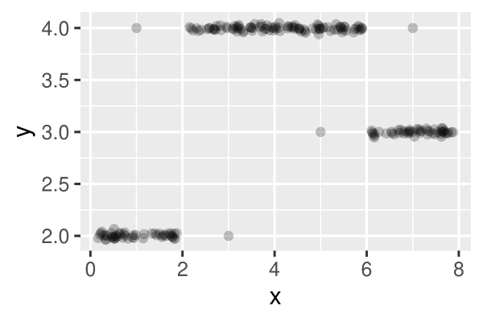

unnamed-chunk-4-1-1.png

The above plot shows $\mathcal{D} = \left( (\mathbf{x}^{(1)}, y^{(1)}), \dots, (\mathbf{x}^{(n)}, y^{(n)}) \right)$, a data set with $n = 200$ observations of a continuous target variable $y$ and a continuous, 1-dimensional feature variable $\mathbf{x}$. In the following, we aim at predicting $y$ with a machine learning model that takes $\mathbf{x}$ as input.

> 1. To prepare the data for classification, we categorize the target variable $y$ in $3$ classes and call the transformed target variable $z$, as follows:

$$z^{(i)} =
\begin{cases}
1, & y^{(i)} \in (-\infty, 2.5] \\
2, & y^{(i)} \in (2.5, 3.5] \\
3, & y^{(i)} \in (3.5, \infty)
\end{cases}$$
> Now we can apply quadratic discriminant analysis (QDA):

> > 1. Estimate the class means $\mu_k = E(\mathbf{x}| z = k)$ for each of the three classes $k \in \{1, 2, 3\}$ visually from the plot. Do not overcomplicate this, a rough estimate is sufficient here.

> > **# Enter your answer here:**
> > 2. Make a plot that visualizes the different estimated densities per class

```
In [15]:
```

```python
# Enter your code here:
```

> > 3. How would your plot from ii) change if we used linear discriminant analysis (LDA) instead of QDA? Explain your answer.

> > **# Enter your answer here:**
> > 4. Why is QDA preferable over LDA for this data?

> > **# Enter your answer here:**
> 2. Given are two new observations $\mathbf{x}_{∗1} = −10$ and $\mathbf{x}_{∗2} = 7$. State the prediction for QDA and explain how you arrive there.

> **# Enter your answer here:**

## Exercise 3: Decision Boundaries for Classification Learners

We will now visualize how well different learners classify the three-class `mlbench::mlbench.cassini` data set. Generate $1000$ points from `cassini` using `R`. Then, perturb the `x.2` dimension with Gaussian noise (mean $0$, standard deviation $0.5$), and consider the classifiers already introduced in the lecture:

- LDA,
- QDA, and
- Naive Bayes.

Plot the learners’ decision boundaries. Can you spot differences in separation ability?  
(Note that logistic regression cannot handle more than two classes and is therefore not listed here.)

```
In [22]:
```

```python
# Enter your code here:
```